# AI & Machine Learning - Unit 2

## Let's try with only 3 Components!

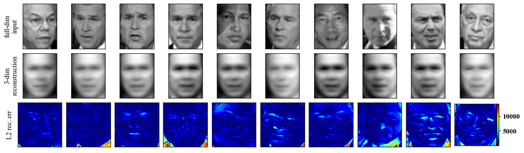

```python
from mpl_toolkits.axes_grid1.axes_divider import make_axes_locatable

############### Fitting with 3 components ######
pca = PCA(n_components=3) # retain 3 components
pca.fit(faces.data)
#############################################
##### Plot
# Project back to the input
projected = pca.transform(faces.data) # project with P = U_t*X_t
unprojected = pca.inverse_transform(projected) # unproject with U*P = U(U_t*X_t)
# Now plot
fig, ax = plt.subplots(3, 10, figsize=(15, 4.5),
                       subplot_kw={'xticks': [], 'yticks': []},
                       gridspec_kw=dict(hspace=0.1, wspace=0.1))

# it is important to get the max value of the error so that
# we plot heatmap error with the SAME SCALE!
errors_img = [(unprojected[i]-faces.data[i])**2 for i in range(10)]
max_val = max([err.max() for err in errors_img])

for i in range(10):
    ax[0, i].imshow(faces.data[i].reshape(62, 47), cmap='gray')
    ax[1, i].imshow(unprojected[i].reshape(62, 47), cmap='gray')
    erri = ax[2, i].imshow((errors_img[i]).reshape(
        62, 47), cmap='jet', extent=[0, max_val]*2)
    if i == 9:
        divider = make_axes_locatable(ax[2, i])
        cax = divider.append_axes("right", size="5%", pad=0.005)
        plt.colorbar(erri, cax=cax)

ax[0, 0].set_ylabel('full-dim\ninput')
ax[1, 0].set_ylabel('3-dim\nreconstruction')
_ = ax[2, 0].set_ylabel('L2 rec. err')
```

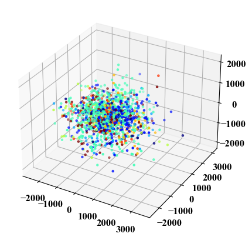

```python
# Nx3
fig = plt.figure(figsize=(5,5))
ax = fig.add_subplot(projection='3d')
_ = ax.scatter(*projected.T, c=faces.target, marker='.', cmap='jet')
```

## Color maps to Identity

### Looks like not a great projection for separating the identity!

### In the end makes sense since PCA is an unsupervised method.

# Another example for PCA on color RGB images on CIFAR-10

[figure not shown]

[Taken from cs231n.github.io/neural-networks-2](https://cs231n.github.io/neural-networks-2/)

## Now I will show you some data and then you need to tell me if using

## PCA is a good way to separate the color of the data

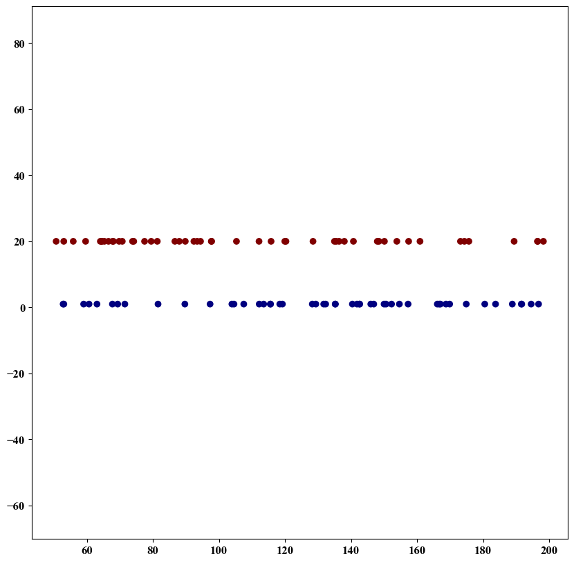

```python
plt.figure(figsize=(10,10))
np.random.seed(0)
N_samples = 50
# samples points for class 1
X_1 = np.random.uniform(50, 200, N_samples)
X_1 = np.vstack((X_1, (1,)*N_samples))
# samples points for class 2
X_2 = np.random.uniform(50, 200, N_samples)
X_2 = np.vstack((X_2, (20,)*N_samples))
X = np.concatenate((X_1, X_2))
# data
X = np.concatenate((X_1, X_2), axis=1)
# labels
labels = X[1, ...]
# Plot also the training points
plt.scatter(
    x=X[0, ...],
    y=X[1, ...],
    c=labels,
    cmap='jet',
)
# Code below wants Nx2
X = X.T
_ = plt.axis('equal')
```

# Why compression

This example is just used for illustrative purposes since **Machine Learning** is much related to **Information Theory**.

[figure not shown]

# How to apply PCA

# Usage of PCA

- **Inductive** (estimate basis on training set); apply on test set - **Most common**
- **Transductive** (get all the points at test time; estimate and project) - **Assumes you have all the points at test time**

## Inductive Settings

Most of the methods covered in this course are **"Inductive"** (as opposed to **transductive**).

- Induction works well for **supervised methods** but can also be applied to **unsupervised methods.**
- **[Training]** Estimate $\mbf{U}$ on a training set (and also mean $\mu$ and std $\sigma$)
- **[Test Time]** Given a new point $\mbf{x}^{\prime}$ at test-time, apply PCA, that is project $\mbf{x}^{\prime}$ with $\mbf{U}, \mu, \sigma$

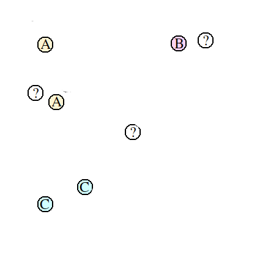

## On the side: Transductive Settings

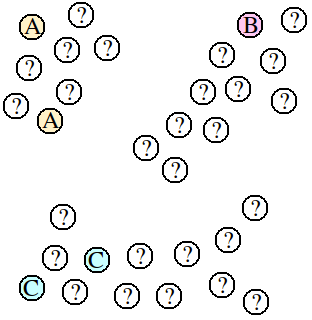

[Vapnik'98 - Learning by Transduction](https://arxiv.org/ftp/arxiv/papers/1301/1301.7375.pdf)